# PM_GWP1_Group_7457

## **Step 1**

**a) (i) Market Risk Premium (MRP)**

The Market Risk Premium (MRP) is an additional return that investors seek for maintaining a market portfolio rather than having a risk-free investment. It is a fundamental element in the Capital Asset Pricing Model (CAPM), and can be defined as an extra return that an investor expects to earn for holding a combination of risky assets instead of government bonds because the latter carries no or low risk.

In the CAPM formula, the expected return of an asset is expressed as:

$$ E(R)_i = R_f + \beta(E(R_m)-R_f) $$ where:

- $R_f$ is the risk-free rate.
- $\beta_i$ is the sensitivity of the asset to the market.
- $E(R_m)-R_f$ is the market risk premium.

This premium is also the price investors place on taking a position in the stock market which carries greater risk compared to a virtually risk-free investment in a treasury bond. The MRP is variable and has linkages with other macroeconomic variables such as the level of inflation, interest rates, and global economic conditions.

**(ii) Small minus Big (SMB)**

The Small Minus Big (SMB) factor reflects the return spread between small-cap and large-cap stocks. It captures the "size effect," which shows that historically, smaller companies tend to outperform larger ones over long periods. SMB is calculated by taking the difference between the returns of a portfolio of small-cap stocks and a portfolio of large-cap stocks:

$$ \text{SMB} = \text{Average return of small-cap stocks} - \text{Average return of large-cap stocks} $$

Consequently, small companies usually have more growth opportunities and therefore enjoy higher expected returns but with greater risk as well. Small-cap equities are more sensitive to economic downturns, are less liquid and have limited fundraising ability, which are all factors to their volatility.

**(iii) High Minus Low (HML)**

The High Minus Low (HML) factor captures the return differential between value stocks and growth stocks. Value stocks are characterized by high book-to-market ratios, meaning they are perceived as undervalued compared to their fundamental metrics, such as book value. Growth stocks, on the other hand, have low book-to-market ratios, indicating high expectations for future earnings growth but may be overpriced relative to their current fundamentals. HML is constructed by taking the difference between the returns of high book-to-market (value) stocks and low book-to-market (growth) stocks:

$$ \text{HML} = \text{Average return of value stocks} - \text{Average return of growth stocks} $$

Fama and French’s HML can be viewed as an example of the value premium, which suggests that value stocks, in the end, outperform growth stocks. Value stocks are perceived as riskier, and these are firms that are distressed or firms in sunset industries. Such stocks carry with them a risk premium which investors typically expect to earn.

**(iv) Conservative Minus Aggressive (CMA)**

The Conservative Minus Aggressive (CMA) factor distinguishes companies with conservative investment policies and those with aggressive investment strategies. Conservative firms tend to carry out less reinvestment of their earnings and such firms also tend to have low levels of capital investment as opposed to aggressive firms that are characterized by high levels of mergers, expansions or new projects that are aimed at reinvesting earnings.

CMA is calculated by taking the difference between the returns of companies with conservative investment policies and those with aggressive policies:

$$ \text{CMA} = \text{Average return of conservative firms} - \text{Average return of aggressive firms} $$

The CMA is one of the factors presented by Fama and French in their Five-Factor Model in 2015. The intuition behind this factor is that such firms which have more conservative investment policies are expected to better the aggressive firms as the latter will be taking risk which does not always yield return as expected.

**(v) Robust Minus Weak (RMW)**

The RMW factor measures the spread of earnings between stronger earnings and weaker earnings and hence provides the difference in the returns between firms with high earnings and those with weak earnings. In most cases, profitability is determined in terms of the gross profit-to-asset ratio or the operating income-to-asset ratio. Companies with robust bid-to-cover ratios and bid premiums tend to have consistent income from their operations. On the other hand, weaker firms can hardly earn steady earnings.

RMW is calculated as:

$$ \text{RMW} = \text{Average return of robust profitability firms} - \text{Average return of weak profitability firms} $$

The RMW factor was introduced by Fama and French in their 2015 five-factor model for explaining the profitability effect, which is ignored by previous models including the three-factor model. This means shares with higher profitability are likely to return dividends to investors since they have the capacity to pay the dividends and still support reinvestment to grow the business, and also withstand unfavorable events. Lower profitability on the other side is associated with higher likelihood of financial distress, lower growth potential, and lower survivability to shocks in the economy.

**b) Why does this factor help explain returns?**

**(i) Market Risk Premium (MRP)**

The MRP is one of the most crucial factors in explaining equity returns because it directly reflects the reward investors demand for taking market risk. When the market is doing well, stocks typically outperform the risk-free rate, so a large MRP means that market returns are predicted to match risk-free assets, hence a higher return. Conversely, a low MRP might indicate a risk-averse landscape, in which investors are unwilling to invest in risky assets. This relationship is key to grasping the costs that investors weigh when choosing the level of risk to include in their portfolios

**(ii) Small minus Big (SMB)**

SMB describes one important feature of returns in the stock market that CAPM does not capture on its own. Smaller companies are, in general, overlooked and underappreciated, shunned by institutional investors, or subject to greater inefficiencies, and their higher long-term returns are thus a reward for the increased risks of their operations. Additionally, small firms often operate in niche markets with higher growth potential compared to large established firms.

**(iii) High Minus Low (HML)**

HML helps to understand the value-growth puzzle in stock returns. Value stocks are often undervalued by the market, and investors who buy these stocks are compensated with higher returns when the market corrects these mispricings. Growth stocks, while promising rapid future growth, tend to be more volatile and riskier in the short term. In the good times, investors have a tendency to drive the price of growth stocks ever higher, which can mean disappointing returns when the penny drops.

**(iv) Conservative Minus Aggressive (CMA)**

CMA explains why models of stock returns become more powerful when they account for a company's investment behavior, which affects its risk and return characteristics. The companies that play it safe will appear less risky, more robust, with dependable, though potentially underwhelming, returns. Aggressive companies are usually in growth or expansion mode, and can provide huge returns if the investments work out, but are also more likely to collapse and fluctuate.

In many cases, conservative companies outperform during periods of market uncertainty or downturns, while aggressive firms may excel during economic booms. The CMA factor can be used to understand this performance gap in terms of the strategic choices that companies make about how they allocate capital.

**(v) Robust Minus Weak (RMW)**

RMW improves the precision of stock returns forecasting by making profitability as a key determinant of how a firms are likely to perform in the long run. Robust firms typically offer higher returns than weak firms, as profitability indicates not only operational efficiency but also a firm’s ability to allocate resources efficiently and sustain a competitive advantage. This factor helps to fill in a hole in the earlier models, which ignored the effect of profitability on stock returns.

Not only does the RMW factor enhance the explanatory power of returns, but it also brings an element of quality into the analysis of investment. Investors who focus on profitability are often concerned with the quality of earnings and management’s ability to maximize shareholder value. So portfolios with an overweighting of strong firms can generate both greater expected returns and less risk than portfolios filled with weak ones.

## **Step 2**

#### **a) Importing, structuring, and graphing of the daily factor returns**

Using a a 3-year time period and daily data for the five factors (MRP, SMB, HML, CMA, RMW), the factor data from Professor Kenneth French’s data library.

```python
import math
from scipy.optimize import brute, fmin
from scipy.integrate import quad
import yfinance as yf
import pandas_datareader as pdr  # Access FRED
import yfinance as yf
from sklearn.preprocessing import MinMaxScaler
import tensorflow as tf
import pandas as pd
import numpy as np
import seaborn as sns
import matplotlib.pyplot as plt
from statsmodels.tsa.stattools import adfuller
import matplotlib.pyplot as plt
from sklearn.model_selection import train_test_split
from sklearn.preprocessing import StandardScaler
from sklearn.metrics import mean_squared_error
from tensorflow.keras.models import Sequential
from tensorflow.keras.layers import Conv2D, MaxPooling2D, Flatten, Dense, Dropout
from tensorflow.keras.layers import Dense, Flatten
from tensorflow.keras.optimizers import Adam
from sklearn.metrics import mean_squared_error
from tensorflow.keras.layers import Dense, LSTM
from sklearn.linear_model import LinearRegression
from sklearn.metrics import mean_squared_error, r2_score
from sklearn.metrics import mean_squared_error, mean_absolute_error
from tensorflow.keras.callbacks import EarlyStopping
from scipy.optimize import minimize
```

```python
import pandas as pd
import zipfile
import io
import requests

# Import the recent Fama-French 5-Factor data
ff5_data_url = 'https://mba.tuck.dartmouth.edu/pages/faculty/ken.french/ftp/F-F_Research_Data_5_Factors_2x3_daily_CSV.zip'
response = requests.get(ff5_data_url)
zipped_file = zipfile.ZipFile(io.BytesIO(response.content))
file_name = zipped_file.namelist()[0]  # The first file in the archive
ff5_factors = pd.read_csv(zipped_file.open(file_name), skiprows=3)
ff5_factors.columns = ['Date', 'Mkt-RF', 'SMB', 'HML', 'RMW', 'CMA', 'RF']
ff5_factors['Date'] = pd.to_datetime(ff5_factors['Date'], format='%Y%m%d')
ff5_factors.set_index('Date', inplace=True)

# Filter the data for the 3-year period 2021-09-01 to 2024-09-01
start_date = '2021-09-01'
end_date = '2024-09-01'
ff5_factors_recent = ff5_factors.loc[start_date:end_date]

# Drop the 'RF' column, as we focus on the 5 factors only
ff5_factors_recent = ff5_factors_recent.drop(columns=['RF'])

print(ff5_factors_recent.head())
```

```
            Mkt-RF   SMB   HML   RMW   CMA
Date
2021-09-01    0.11  0.39 -0.93 -0.42 -0.37
2021-09-02    0.36  0.21 -0.04 -0.43  0.58
2021-09-03   -0.01 -0.55 -0.27  0.04 -0.28
2021-09-07   -0.36 -0.37 -0.08 -0.59  0.17
2021-09-08   -0.34 -0.74  0.08  0.75  0.19
```

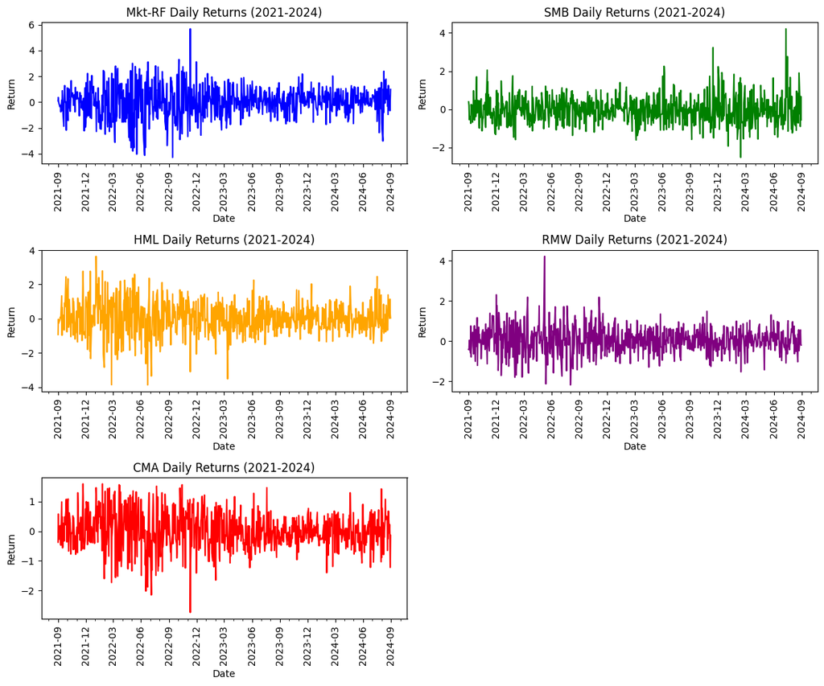

```python
import matplotlib.pyplot as plt
import matplotlib.dates as mdates
import numpy as np

colors = ['blue', 'green', 'orange', 'purple', 'red']
fig, axes = plt.subplots(3, 2, figsize=(12, 10))
factor_names = ['Mkt-RF', 'SMB', 'HML', 'RMW', 'CMA']

for i, factor in enumerate(factor_names):
    row, col = divmod(i, 2)
    ax = axes[row, col]

    ax.plot(ff5_factors_recent.index, ff5_factors_recent[factor], label=factor, color=colors[i])
    ax.set_title(f'{factor} Daily Returns (2021-2024)')
    ax.set_xlabel('Date')
    ax.set_ylabel('Return')
    ax.xaxis.set_major_locator(mdates.MonthLocator(interval=3))  # Major ticks every 3 months
    ax.xaxis.set_minor_locator(mdates.MonthLocator())  # Minor ticks for every month
    ax.xaxis.set_major_formatter(mdates.DateFormatter('%Y-%m'))  # Format the dates as YYYY-MM
    plt.setp(ax.xaxis.get_majorticklabels(), rotation=90)
    plt.setp(ax.xaxis.get_minorticklabels(), rotation=90, fontsize='small')  # Smaller font for minor ticks

fig.delaxes(axes[2, 1])

plt.tight_layout()
plt.show()
```

#### **b) Collect and Compute Correlations of the Changes in Factor Returns**

To compute the correlations of the changes in the factor returns, we will first calculate the daily returns for each factor, then compute the correlation matrix for these daily returns.

```python
daily_returns = ff5_factors_recent.pct_change().dropna()

correlation_matrix = daily_returns.corr()

print("Correlation Matrix of Daily Factor Returns:")
print(correlation_matrix)
```

```
Correlation Matrix of Daily Factor Returns:
          Mkt-RF       SMB       HML       RMW       CMA
Mkt-RF  1.000000 -0.037117 -0.043794  0.001403  0.015672
SMB    -0.037117  1.000000  0.006820 -0.041240 -0.007376
HML    -0.043794  0.006820  1.000000 -0.025043  0.056083
RMW     0.001403 -0.041240 -0.025043  1.000000 -0.019680
CMA     0.015672 -0.007376  0.056083 -0.019680  1.000000
```

#### **c) Collecting a 10-year Treasury Rates during the 3-year period**

```python
import yfinance as yf
import pandas as pd

ticker = '^TNX'  # 10-Year Treasury Yield

start_date = '2021-09-01'
end_date = '2024-09-01'

treasury_data = yf.download(ticker, start=start_date, end=end_date)

treasury_yield = treasury_data['Close']

print("10-Year Treasury Yield Data (First 5 Rows):")
print(treasury_yield.head())

print("\n10-Year Treasury Yield Data (Last 5 Rows):")
print(treasury_yield.tail())
```

```
[*********************100%***********************]  1 of 1 completed
```

```
10-Year Treasury Yield Data (First 5 Rows):
Ticker                      ^TNX
Date
2021-09-01 00:00:00+00:00  1.302
2021-09-02 00:00:00+00:00  1.294
2021-09-03 00:00:00+00:00  1.322
2021-09-07 00:00:00+00:00  1.370
2021-09-08 00:00:00+00:00  1.334

10-Year Treasury Yield Data (Last 5 Rows):
Ticker                      ^TNX
Date
2024-08-26 00:00:00+00:00  3.818
2024-08-27 00:00:00+00:00  3.833
2024-08-28 00:00:00+00:00  3.841
2024-08-29 00:00:00+00:00  3.867
2024-08-30 00:00:00+00:00  3.911
```

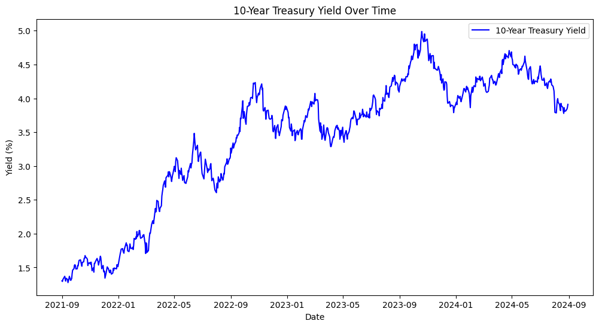

```python
plt.figure(figsize=(12, 6))
plt.plot(treasury_yield, label='10-Year Treasury Yield', color='blue')
plt.title('10-Year Treasury Yield Over Time')
plt.xlabel('Date')
plt.ylabel('Yield (%)')
plt.legend()
plt.show()
```

## **Step 3**

```python
import statsmodels.api as sm
from statsmodels.robust.norms import HuberT
import numpy as np
```

```python
treasury_yield_changes = treasury_yield.pct_change().dropna()
X_ff3 = ff5_factors_recent[['Mkt-RF', 'SMB', 'HML']]

y_treasury = treasury_yield_changes
```

```python
X_ff3.index = X_ff3.index.tz_localize(None)
y_treasury.index = y_treasury.index.tz_localize(None)

aligned_data_ff3 = pd.concat([X_ff3, y_treasury], axis=1).dropna()
X_ff3_aligned = aligned_data_ff3[['Mkt-RF', 'SMB', 'HML']]
y_ff3_treasury = aligned_data_ff3['^TNX']

X_ff3_aligned = sm.add_constant(X_ff3_aligned)
```

```python
train_size = int(len(X_ff3_aligned) * 0.8)
X_train_ff3, X_test_ff3 = X_ff3_aligned[:train_size], X_ff3_aligned[train_size:]
y_train_ff3, y_test_ff3 = y_ff3_treasury[:train_size], y_ff3_treasury[train_size:]
```

```python
ols_model_ff3 = sm.OLS(y_train_ff3, X_train_ff3).fit()
print("OLS Regression Results (FF3):\n", ols_model_ff3.summary())
```

```
OLS Regression Results (FF3):
                             OLS Regression Results
==============================================================================
Dep. Variable:                   ^TNX   R-squared:                       0.057
Model:                            OLS   Adj. R-squared:                  0.052
Method:                 Least Squares   F-statistic:                     12.07
Date:                Thu, 31 Oct 2024   Prob (F-statistic):           1.12e-07
Time:                        14:22:24   Log-Likelihood:                 1386.0
No. Observations:                 602   AIC:                            -2764.
Df Residuals:                     598   BIC:                            -2746.
Df Model:                           3
Covariance Type:            nonrobust
==============================================================================
                 coef    std err          t      P>|t|      [0.025      0.975]
------------------------------------------------------------------------------
const          0.0019      0.001      1.932      0.054   -3.12e-05       0.004
Mkt-RF         0.0018      0.001      2.017      0.044    4.83e-05       0.004
SMB           -0.0024      0.002     -1.558      0.120      -0.006       0.001
HML            0.0064      0.001      5.924      0.000       0.004       0.009
==============================================================================
Omnibus:                       10.992   Durbin-Watson:                   2.066
Prob(Omnibus):                  0.004   Jarque-Bera (JB):               18.405
Skew:                          -0.059   Prob(JB):                     0.000101
Kurtosis:                       3.848   Cond. No.                         2.21
==============================================================================

Notes:
[1] Standard Errors assume that the covariance matrix of the errors is correctly specified.
```

```python
robust_model_ff3 = sm.RLM(y_train_ff3, X_train_ff3, M=HuberT()).fit()
print("Robust Regression Results (FF3):\n", robust_model_ff3.summary())
```

```
Robust Regression Results (FF3):
                     Robust linear Model Regression Results
==============================================================================
Dep. Variable:                   ^TNX   No. Observations:                  602
Model:                            RLM   Df Residuals:                      598
Method:                          IRLS   Df Model:                            3
Norm:                          HuberT
Scale Est.:                       mad
Cov Type:                          H1
Date:                Thu, 31 Oct 2024
Time:                        14:22:25
No. Iterations:                    20
==============================================================================
                 coef    std err          z      P>|z|      [0.025      0.975]
------------------------------------------------------------------------------
const          0.0020      0.001      2.105      0.035       0.000       0.004
Mkt-RF         0.0016      0.001      1.859      0.063   -8.76e-05       0.003
SMB           -0.0028      0.001     -1.912      0.056      -0.006    7.07e-05
HML            0.0059      0.001      5.791      0.000       0.004       0.008
==============================================================================

If the model instance has been used for another fit with different fit parameters, then the fit options might not be the correct ones anymore .
```

## **Step 4**

```python
X_ff5 = ff5_factors_recent[['Mkt-RF', 'SMB', 'HML', 'RMW', 'CMA']]
y_treasury_ff5 = treasury_yield_changes

X_ff5.index = X_ff5.index.tz_localize(None)
y_treasury_ff5.index = y_treasury_ff5.index.tz_localize(None)
```

```python
aligned_data_ff5 = pd.concat([X_ff5, y_treasury_ff5], axis=1).dropna()
X_ff5_aligned = aligned_data_ff5[['Mkt-RF', 'SMB', 'HML', 'RMW', 'CMA']]
y_ff5_treasury = aligned_data_ff5['^TNX']

X_ff5_aligned = sm.add_constant(X_ff5_aligned)
```

```python
train_size = int(len(X_ff5_aligned) * 0.8)
X_train_ff5, X_test_ff5 = X_ff5_aligned[:train_size], X_ff5_aligned[train_size:]
y_train_ff5, y_test_ff5 = y_ff5_treasury[:train_size], y_ff5_treasury[train_size:]
```

```python
ols_model_ff5 = sm.OLS(y_train_ff5, X_train_ff5).fit()
print("OLS Regression Results (FF5):\n", ols_model_ff5.summary())
```

```
OLS Regression Results (FF5):
                             OLS Regression Results
==============================================================================
Dep. Variable:                   ^TNX   R-squared:                       0.072
Model:                            OLS   Adj. R-squared:                  0.065
Method:                 Least Squares   F-statistic:                     9.303
Date:                Thu, 31 Oct 2024   Prob (F-statistic):           1.52e-08
Time:                        14:22:25   Log-Likelihood:                 1391.0
No. Observations:                 602   AIC:                            -2770.
Df Residuals:                     596   BIC:                            -2744.
Df Model:                           5
Covariance Type:            nonrobust
==============================================================================
                 coef    std err          t      P>|t|      [0.025      0.975]
------------------------------------------------------------------------------
const          0.0020      0.001      2.051      0.041    8.61e-05       0.004
Mkt-RF         0.0010      0.001      1.002      0.317      -0.001       0.003
SMB           -0.0050      0.002     -2.831      0.005      -0.009      -0.002
HML            0.0097      0.002      5.842      0.000       0.006       0.013
RMW           -0.0047      0.002     -2.619      0.009      -0.008      -0.001
CMA           -0.0048      0.003     -1.832      0.067      -0.010       0.000
==============================================================================
Omnibus:                       10.473   Durbin-Watson:                   2.074
Prob(Omnibus):                  0.005   Jarque-Bera (JB):               17.249
Skew:                          -0.054   Prob(JB):                     0.000180
Kurtosis:                       3.822   Cond. No.                         4.50
==============================================================================

Notes:
[1] Standard Errors assume that the covariance matrix of the errors is correctly specified.
```

```python
robust_model_ff5 = sm.RLM(y_train_ff5, X_train_ff5, M=HuberT()).fit()
print("Robust Regression Results (FF5):\n", robust_model_ff5.summary())
```

```
Robust Regression Results (FF5):
                     Robust linear Model Regression Results
==============================================================================
Dep. Variable:                   ^TNX   No. Observations:                  602
Model:                            RLM   Df Residuals:                      596
Method:                          IRLS   Df Model:                            5
Norm:                          HuberT
Scale Est.:                       mad
Cov Type:                          H1
Date:                Thu, 31 Oct 2024
Time:                        14:22:25
No. Iterations:                    18
==============================================================================
                 coef    std err          z      P>|z|      [0.025      0.975]
------------------------------------------------------------------------------
const          0.0021      0.001      2.175      0.030       0.000       0.004
Mkt-RF         0.0009      0.001      0.996      0.319      -0.001       0.003
SMB           -0.0049      0.002     -2.860      0.004      -0.008      -0.002
HML            0.0086      0.002      5.356      0.000       0.005       0.012
RMW           -0.0040      0.002     -2.342      0.019      -0.007      -0.001
CMA           -0.0036      0.002     -1.454      0.146      -0.009       0.001
==============================================================================

If the model instance has been used for another fit with different fit parameters, then the fit options might not be the correct ones anymore .
```

## **Step 5**

```python
correlation_matrix = ff5_factors_recent.corr()
print("Correlation Matrix of Daily Factor Returns:\n", correlation_matrix)
```

```
Correlation Matrix of Daily Factor Returns:
           Mkt-RF       SMB       HML       RMW       CMA
Mkt-RF  1.000000  0.208883 -0.389031 -0.359160 -0.471361
SMB     0.208883  1.000000  0.101063 -0.447998 -0.060949
HML    -0.389031  0.101063  1.000000  0.364863  0.719890
RMW    -0.359160 -0.447998  0.364863  1.000000  0.322208
CMA    -0.471361 -0.060949  0.719890  0.322208  1.000000
```

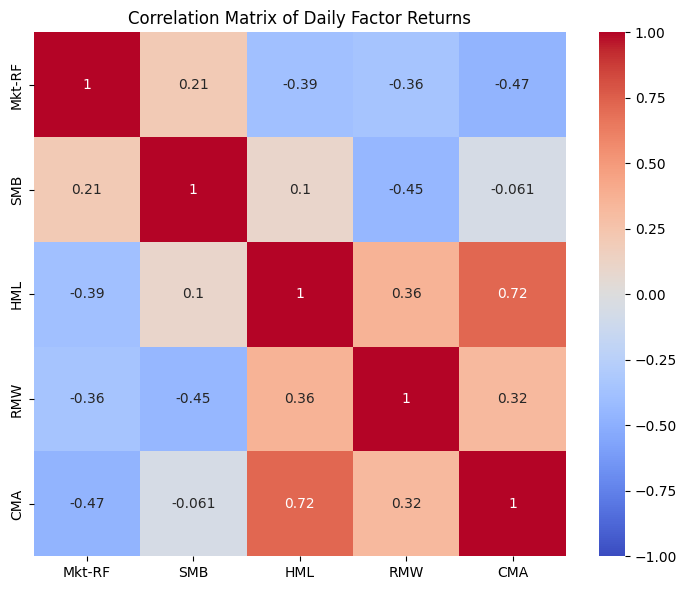

```python
plt.figure(figsize=(14, 6))
plt.subplot(1, 2, 1)
sns.heatmap(correlation_matrix, annot=True, cmap='coolwarm', vmin=-1, vmax=1)
plt.title("Correlation Matrix of Daily Factor Returns")
plt.tight_layout()
plt.show()
```

```python
covariance_matrix = ff5_factors_recent.cov()
print("\nCovariance Matrix of Daily Factor Returns:\n", covariance_matrix)
```

```
Covariance Matrix of Daily Factor Returns:
           Mkt-RF       SMB       HML       RMW       CMA
Mkt-RF  1.342741  0.171043 -0.432316 -0.278159 -0.342076
SMB     0.171043  0.499355  0.068488 -0.211587 -0.026974
HML    -0.432316  0.068488  0.919688  0.233862  0.432374
RMW    -0.278159 -0.211587  0.233862  0.446702  0.134871
CMA    -0.342076 -0.026974  0.432374  0.134871  0.392234
```

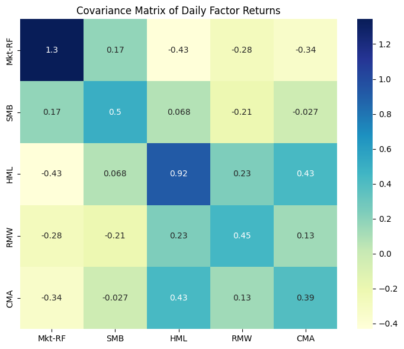

```python
plt.figure(figsize=(14, 6))
plt.subplot(1, 2, 1)
sns.heatmap(covariance_matrix, annot=True, cmap='YlGnBu')
plt.title("Covariance Matrix of Daily Factor Returns")
plt.tight_layout()
plt.show()
```

## **Step 6**

```python
ff3_coefficients = ols_model_ff3.params
ff5_coefficients = ols_model_ff5.params

ff3_r_squared = ols_model_ff3.rsquared
ff3_adj_r_squared = ols_model_ff3.rsquared_adj
ff5_r_squared = ols_model_ff5.rsquared
ff5_adj_r_squared = ols_model_ff5.rsquared_adj
```

```python
results_comparison = pd.DataFrame({
    "FF3 Model": [ff3_coefficients.get("const", np.nan), ff3_coefficients["Mkt-RF"], ff3_coefficients["SMB"], ff3_coefficients["HML"], None, None, ff3_r_squared, ff3_adj_r_squared],
    "FF5 Model": [ff5_coefficients.get("const", np.nan), ff5_coefficients["Mkt-RF"], ff5_coefficients["SMB"], ff5_coefficients["HML"], ff5_coefficients["RMW"], ff5_coefficients["CMA"], ff5_r_squared, ff5_adj_r_squared]
}, index=["Intercept", "Mkt-RF", "SMB", "HML", "RMW", "CMA", "R-squared", "Adjusted R-squared"])
```

```python
print("Comparison of FF3 and FF5 Model Results:\n")
results_comparison
```

```
Comparison of FF3 and FF5 Model Results:
```

|  | FF3 Model | FF5 Model |
| --- | --- | --- |
| Intercept | 0.001916 | 0.002022 |
| Mkt-RF | 0.001841 | 0.000965 |
| SMB | -0.002440 | -0.005026 |
| HML | 0.006386 | 0.009714 |
| RMW | NaN | -0.004661 |
| CMA | NaN | -0.004761 |
| R-squared | 0.057080 | 0.072394 |
| Adjusted R-squared | 0.052350 | 0.064612 |

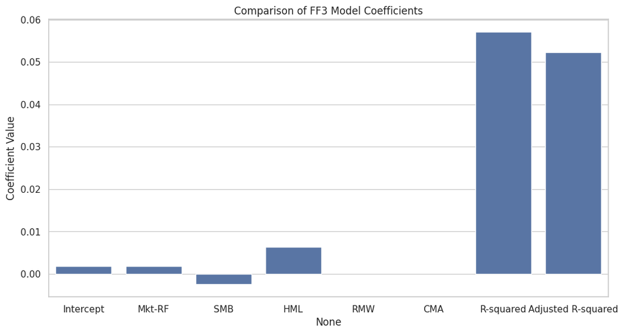

```python
plt.figure(figsize=(12, 6))
sns.set(style="whitegrid")
sns.barplot(x=results_comparison.index, y="FF3 Model", data=results_comparison)
plt.title("Comparison of FF3 Model Coefficients")
plt.ylabel("Coefficient Value")
plt.show()
```

```python
def model_metrics(model, X, y):
    predictions = model.predict(X)
    residuals = y - predictions
    mse = np.mean(residuals**2)  # Mean Squared Error
    rmse = np.sqrt(mse)  # Root Mean Squared Error
    mae = np.mean(np.abs(residuals))  # Mean Absolute Error
    return mse, rmse, mae
```

```python
ols_mse_ff3, ols_rmse_ff3, ols_mae_ff3 = model_metrics(ols_model_ff3, X_test_ff3, y_test_ff3)
robust_mse_ff3, robust_rmse_ff3, robust_mae_ff3 = model_metrics(robust_model_ff3, X_test_ff3, y_test_ff3)
ols_mse_ff5, ols_rmse_ff5, ols_mae_ff5 = model_metrics(ols_model_ff5, X_test_ff5, y_test_ff5)
robust_mse_ff5, robust_rmse_ff5, robust_mae_ff5 = model_metrics(robust_model_ff5, X_test_ff5, y_test_ff5)

pd.DataFrame({
    "FF3 Model": [ols_mse_ff3, ols_rmse_ff3, ols_mae_ff3, robust_mse_ff3, robust_rmse_ff3, robust_mae_ff3],
    "FF5 Model": [ols_mse_ff5, ols_rmse_ff5, ols_mae_ff5, robust_mse_ff5, robust_rmse_ff5, robust_mae_ff5]
    }, index=["OLS model MSE", "OLS model RMSE", "OLS model MAE", "Robust model MSE", "Robust model RMSE", "Robust model MAE"])
```

|  | FF3 Model | FF5 Model |
| --- | --- | --- |
| OLS model MSE | 0.000226 | 0.000224 |
| OLS model RMSE | 0.015017 | 0.014971 |
| OLS model MAE | 0.012169 | 0.012063 |
| Robust model MSE | 0.000221 | 0.000219 |
| Robust model RMSE | 0.014853 | 0.014790 |
| Robust model MAE | 0.012030 | 0.011922 |

## **Step 7**

```python
start_date = '2021-09-01'
end_date = '2024-09-01'
stocks = ['MSFT', 'NFLX', 'TSLA', 'NVDA', 'JNJ']
stock_data = yf.download(stocks, start=start_date, end=end_date)['Adj Close']
daily_returns = stock_data.pct_change().dropna()
```

```
[*********************100%***********************]  5 of 5 completed
```

```python
def portfolio_performance(weights, returns):
    portfolio_return = np.sum(weights * returns.mean()) * 252  # Annualize returns
    portfolio_volatility = np.sqrt(np.dot(weights.T, np.dot(returns.cov() * 252, weights)))  # Annualize volatility
    return portfolio_return, portfolio_volatility

def minimize_volatility(weights, returns):
    return portfolio_performance(weights, returns)[1]
```

```python
num_stocks = len(stocks)
initial_weights = np.ones(num_stocks) / num_stocks
bounds = [(-1, 1) for _ in range(num_stocks)]
constraints = {'type': 'eq', 'fun': lambda x: np.sum(x) - 1}
```

```python
opt_results = minimize(minimize_volatility, initial_weights, args=(daily_returns,),
                       method='SLSQP', bounds=bounds, constraints=constraints)
optimal_weights = opt_results.x
print("Optimal Portfolio Weights:\n", dict(zip(stocks, optimal_weights)))
```

```
Optimal Portfolio Weights:
 {'MSFT': 0.7694341309093241, 'NFLX': 0.18903836366175678, 'TSLA': 0.023894151035043592, 'NVDA': 0.0011792340965532406, 'JNJ': 0.016454120297322287}
```

```python
opt_return, opt_volatility = portfolio_performance(optimal_weights, daily_returns)
print("Optimal Portfolio Return:", opt_return)
print("Optimal Portfolio Volatility:", opt_volatility)
```

```
Optimal Portfolio Return: 0.05735841388095166
Optimal Portfolio Volatility: 0.14939315279222892
```

```python
target_returns = np.linspace(0.1, 0.3, 50)
efficient_frontier = []
for target in target_returns:
    constraints = [{'type': 'eq', 'fun': lambda x: np.sum(x) - 1},
                   {'type': 'eq', 'fun': lambda x: portfolio_performance(x, daily_returns)[0] - target}]
    opt_results = minimize(minimize_volatility, initial_weights, args=(daily_returns,),
                           method='SLSQP', bounds=bounds, constraints=constraints)
    if opt_results.success:
        efficient_frontier.append(portfolio_performance(opt_results.x, daily_returns)[1])
```

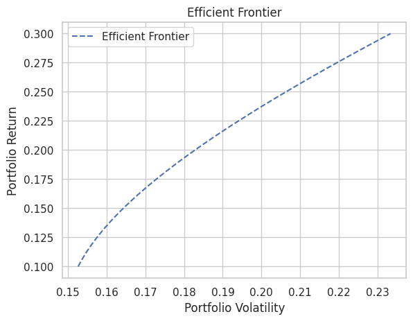

```python
plt.plot(efficient_frontier, target_returns, 'b--', label='Efficient Frontier')
plt.xlabel('Portfolio Volatility')
plt.ylabel('Portfolio Return')
plt.title('Efficient Frontier')
plt.legend()
plt.show()
```

```python
# FF3
X_ff3 = ff5_factors_recent[['Mkt-RF', 'SMB', 'HML']]
y_portfolio = daily_returns.dot(optimal_weights)
y_portfolio = pd.DataFrame(y_portfolio, columns=['Portfolio Return'])
X_ff3.index = X_ff3.index.tz_localize(None)
y_portfolio.index = y_portfolio.index.tz_localize(None)
aligned_data_ff3 = pd.concat([X_ff3, y_portfolio], axis=1).dropna()
X_3f = aligned_data_ff3[['Mkt-RF', 'SMB', 'HML']]
y_portfolio = aligned_data_ff3['Portfolio Return']

X_3f = sm.add_constant(X_3f)

ff3_model = sm.OLS(y_portfolio, X_3f).fit()

print("\nFF3 Model Summary:\n", ff3_model.summary())
```

```
FF3 Model Summary:
                             OLS Regression Results
==============================================================================
Dep. Variable:       Portfolio Return   R-squared:                       0.487
Model:                            OLS   Adj. R-squared:                  0.485
Method:                 Least Squares   F-statistic:                     236.6
Date:                Thu, 31 Oct 2024   Prob (F-statistic):          5.69e-108
Time:                        14:22:53   Log-Likelihood:                 2360.7
No. Observations:                 753   AIC:                            -4713.
Df Residuals:                     749   BIC:                            -4695.
Df Model:                           3
Covariance Type:            nonrobust
==============================================================================
                 coef    std err          t      P>|t|      [0.025      0.975]
------------------------------------------------------------------------------
const          0.0009      0.000      2.440      0.015       0.000       0.002
Mkt-RF         0.0086      0.000     22.846      0.000       0.008       0.009
SMB           -0.0041      0.001     -7.281      0.000      -0.005      -0.003
HML           -0.0011      0.000     -2.577      0.010      -0.002      -0.000
==============================================================================
Omnibus:                      194.230   Durbin-Watson:                   2.079
Prob(Omnibus):                  0.000   Jarque-Bera (JB):             1199.533
Skew:                           1.008   Prob(JB):                    3.35e-261
Kurtosis:                       8.845   Cond. No.                         2.02
==============================================================================

Notes:
[1] Standard Errors assume that the covariance matrix of the errors is correctly specified.
```

```python
# FF5
X_ff5 = ff5_factors_recent[['Mkt-RF', 'SMB', 'HML', 'RMW', 'CMA']]
y_portfolio = daily_returns.dot(optimal_weights)
y_portfolio = pd.DataFrame(y_portfolio, columns=['Portfolio Return'])
X_ff5.index = X_ff5.index.tz_localize(None)
y_portfolio.index = y_portfolio.index.tz_localize(None)
aligned_data_ff5 = pd.concat([X_ff5, y_portfolio], axis=1).dropna()
X_5f = aligned_data_ff5[['Mkt-RF', 'SMB', 'HML', 'RMW', 'CMA']]
y_portfolio = aligned_data_ff5['Portfolio Return']

X_5f = sm.add_constant(X_5f)

ff5_model = sm.OLS(y_portfolio, X_5f).fit()

print("\nFF5 Model Summary:\n", ff5_model.summary())
```

```
FF5 Model Summary:
                             OLS Regression Results
==============================================================================
Dep. Variable:       Portfolio Return   R-squared:                       0.493
Model:                            OLS   Adj. R-squared:                  0.489
Method:                 Least Squares   F-statistic:                     145.0
Date:                Thu, 31 Oct 2024   Prob (F-statistic):          1.80e-107
Time:                        14:22:53   Log-Likelihood:                 2365.1
No. Observations:                 753   AIC:                            -4718.
Df Residuals:                     747   BIC:                            -4690.
Df Model:                           5
Covariance Type:            nonrobust
==============================================================================
                 coef    std err          t      P>|t|      [0.025      0.975]
------------------------------------------------------------------------------
const          0.0009      0.000      2.339      0.020       0.000       0.002
Mkt-RF         0.0087      0.000     22.304      0.000       0.008       0.009
SMB           -0.0032      0.001     -4.901      0.000      -0.004      -0.002
HML           -0.0017      0.001     -2.684      0.007      -0.003      -0.000
RMW            0.0022      0.001      2.948      0.003       0.001       0.004
CMA        -1.786e-05      0.001     -0.019      0.985      -0.002       0.002
==============================================================================
Omnibus:                      181.454   Durbin-Watson:                   2.090
Prob(Omnibus):                  0.000   Jarque-Bera (JB):             1036.188
Skew:                           0.955   Prob(JB):                    9.88e-226
Kurtosis:                       8.420   Cond. No.                         3.89
==============================================================================

Notes:
[1] Standard Errors assume that the covariance matrix of the errors is correctly specified.
```

## **References**

- Bodie, Z., Kane, A., & Marcus, A. J. (2014). Investments (10th ed.).McGraw-Hill Education.
- Fama, E. F., & French, K. R. (1992). The Cross-Section of Expected Stock Returns. The Journal of Finance, 47(2), 427-465.
- Banz, R. W. (1981). The Relationship Between Return and Market Value of Common Stocks. Journal of Financial Economics, 9(1), 3-18.
- Fama, E. F., & French, K. R. (1993). Common Risk Factors in the Returns on Stocks and Bonds. Journal of Financial Economics, 33(1), 3-56.
- Fama, E. F., & French, K. R. (1998). Value Versus Growth: The International Evidence. The Journal of Finance, 53(6), 1975-1999.
- Lakonishok, J., Shleifer, A., & Vishny, R. W. (1994). Contrarian Investment, Extrapolation, and Risk. The Journal of Finance, 49(5), 1541-1578
- Fama, E. F., & French, K. R. (2015). A Five-Factor Asset Pricing Model. Journal of Financial Economics, 116(1), 1-22.
- Titman, S., Wei, K. C., & Xie, F. (2004). Capital Investments and Stock Returns. Journal of Financial and Quantitative Analysis, 39(4), 677-700.
- Novy-Marx, R. (2013). The Other Side of Value: The Gross Profitability Premium. Journal of Financial Economics, 108(1), 1-28.